# An Analysis of the Impact of World Events on CO2 Levels

Fiona McLean

## The Problem

Carbon Dioxide (CO2) levels are of great concern due to the impact that CO2 has on the environment. The levels of CO2 in the atmosphere cause global climate warming, which has significant and disastrous long term consequences for life on Earth. To better understand how and why CO2 levels are changing, an analysis of CO2 levels throughout history was performed. Carbon Dioxide concentrations from an observatory in Hawaii, made available by the Scripps CO2 Program was used in the analysis. It was determined that CO2 levels have been increasing consistently since 1960 until the present. However, the rate of increase is different depending on the time period. In order to determine how the rate of increase is effected by world events, we analyzed CO2 rates during six significant time periods in history. These major world events are the OPEC oil embargo which began in October 1973, the global economic recessions around 1980-1982, the fall of the Berlin wall almost exactly 30 years ago, preceding a dramatic fall in industrial production in the Soviet Union and Eastern Europe, China joining the WTO on 11 December 2001, which was followed by rapid growth in industrial production, the bankruptcy of Lehman Brothers on 15 September 2008, regarded as the symbolic start of the most recent global financial crisis, and the signing of the Paris Agreement on 12 December 2015, intended to limit CO2 emissions. Analyzing if these events effect the rate of increase of CO2 emissions can provide us insight into what causes these emission rates, and how future events may effect them.

## The Model

The figures below show that CO2 emissions have been increasing through history and that emission rates are seasonal. However, to understand how the increase in emission rates have changed over time, and how they may change in the future, modelling the data is necessary.

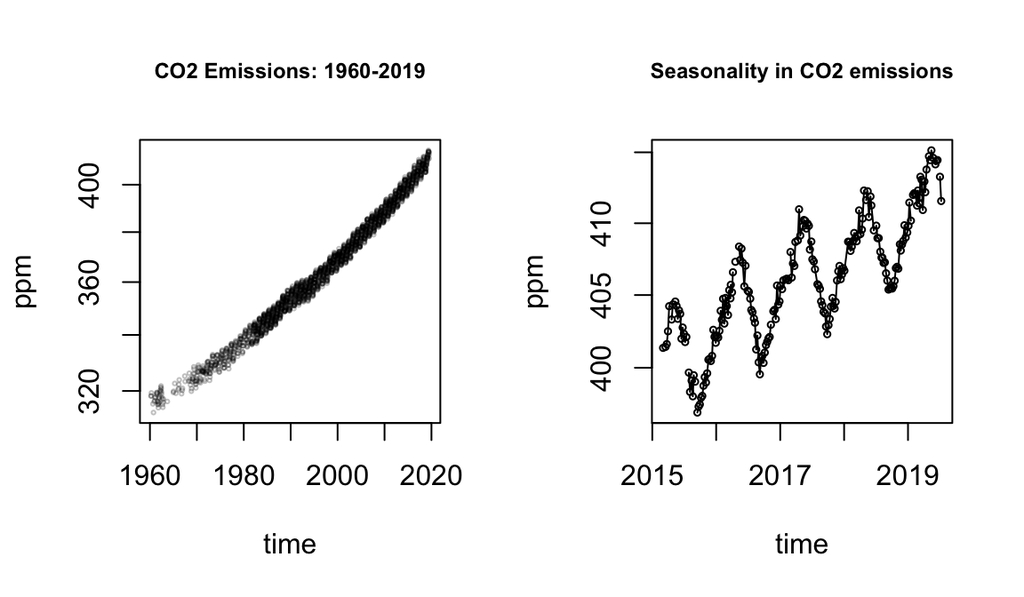

The charts above show a strong increase in CO2 levels over time. We can also see that there is a significant amount of seasonality involved in CO2 emissions. We must take this into account in the model

A Bayesian semi-parametric model was created to determine how the rate of CO2 emissions change over time. Bayesian models allow prior information to be incorporated into a model by specifying a prior and allow for complex models with many random variance factors to be fit, providing advantages over a frequentest model. The fixed effects in the model are sin’s and cos’s which allow us to model seasonal effects. A random walk is included in the model to allow us to make predictions. We use a random walk 2, since we expect that the trend will continue in a linear fashion once data is no longer available. A semi-parametric model was chosen, since it allows us to model the change in CO2 in a non-linear fashion, or in a non-parametric way. As the level of CO2 over time is likely non-linear, this helps to fit a more accurate model. We modeled the CO2 levels with a Gamma distribution, since CO2 levels are always positive and the distribution of the data is not symmetrical.

$Y_{i} \sim \Gamma (\frac{\mu_i}{\nu_{i}}, \beta)$  
$log(\mu_{i}) = X_{i}\beta + U(t_{i})$  
$U(t)-2U(t-1)+U(t-2) \sim N(0,\sigma^2_{u})$, where:

- $(\frac{\mu_i}{\nu_{i}}, \beta)$ are the shape and scale parameters
- $Y_i$ is the CO2 levels measured in ppm at a date $i$
- $X_i\beta$ is the matrix of covariates, has an intercept and are seasonal fixed effects
- $U(t)$ is a second-order random walk.

The priors are:

- $\beta_0 \sim N(0,\infty)$
- $\beta_{i} \sim N(0, 1000)$
- $\sigma^2_{\mu}$ follows an exponential distribution with a median of $\frac{\log (1.01)}{26}$

The priors for the fixed effects were chosen to follow a normal distribution with mean 0 and standard deviation 1000 and standard deviation $\infty$ for the intercept, since the prior is uninformative. The prior on standard deviation for the random walk was chosen to be an exponential distribution with $\mu$ = log(1.01)/26 and $\alpha$ = .5. This prior was chosen because we believe that CO2 levels will only increase more than 1% every half year. We set the $\alpha$ to .5 because half the time we believe the actual increase will be higher than 1% every half year.

## The Analysis

As our main goal is to determine how certain world events effect the CO2 levels worldwide, it is necessary to plot the estimated smoothed trend of CO2 derived from the model above, and discuss whether it appears shallower or steeper after the events listed above. If the trend is shallower, then it suggests a slowing down in the rate of increase in CO2 emissions. A steep trend shows an acceleration in the rate of CO2 emissions.

We are mainly interested in understanding how:

- the OPEC oil embargo which began in October 1973 and ended in March 1974
- the global economic recessions around 1980-1982
- the fall of the Berlin wall almost exactly 30 years ago, preceding a dramatic fall in industrial production in the Soviet Union and Eastern Europe
- China joining the WTO on 11 December 2001, which was followed by rapid growth in industrial production
- the bankruptcy of Lehman Brothers on 15 September 2008, regarded as the symbolic start of the most recent global financial crisis
- the signing of the Paris Agreement on 12 December 2015, intended to limit CO2 emissions

The first graph shows the smoothing function over time, with predictions for CO2 levels in the future. The smoothing function is nearly linear with some inflections. We focus on the dates we are interested to see if there exists inflections at these dates. This allows us to determine if the events have caused a change in CO2 emission rates.

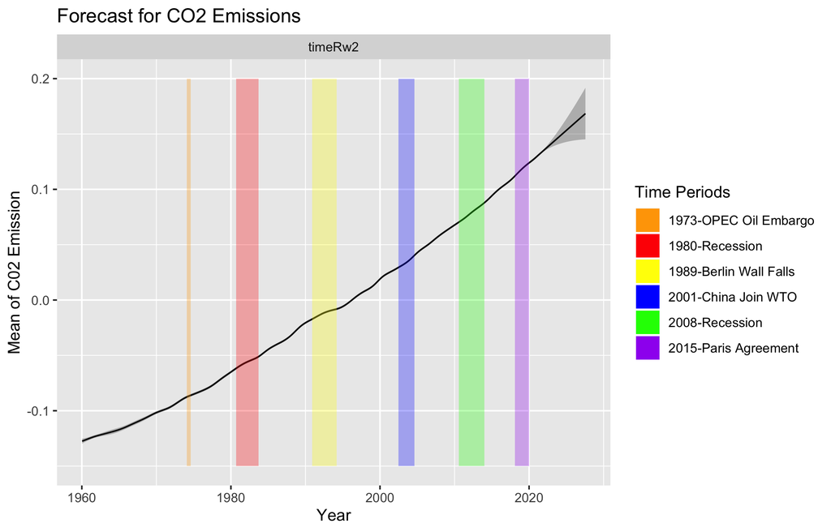

The figure above shows how CO2 levels are changing over time. The smoothing function is nearly linear with some inflections.

The graph is most useful to see that CO2 rates have never decreased since 1960. Therefore, when looking at inflections, we are looking to see if the rate of increase of CO2 rates decreased or increased at the time of the event. However, it is important to note that CO2 rates never actually decrease. To see the inflections more easily, a graph of the rate of change in CO2 levels over time, as well as the CI (credible intervals) of the rate of change is created.

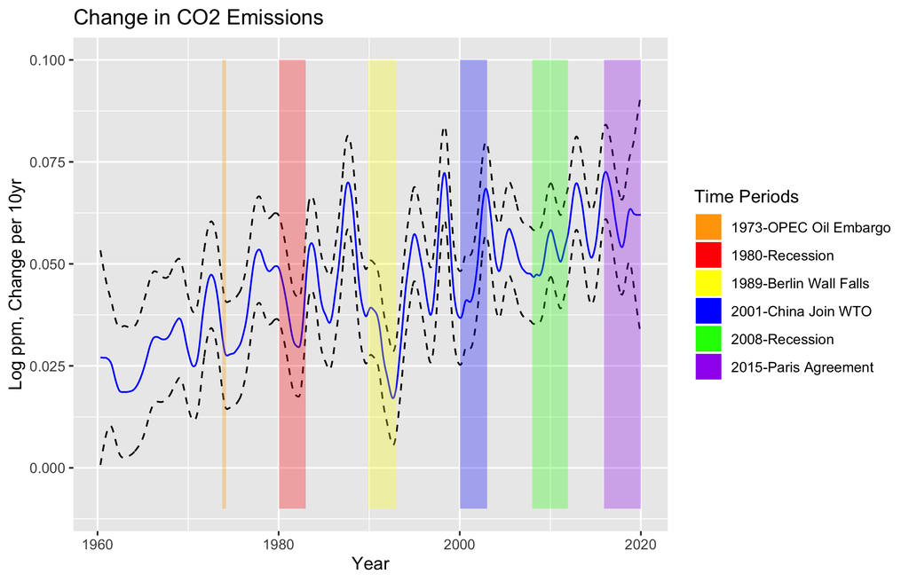

The figure above shows the rate of change in CO2 levels over time. The derivative of the smoothing function allows us to more clearly see inflections.

The chart above allows us to assert that:

- We see very little indication of an effect of the OPEC oil embargo during the duration of the embargo. The rate of CO2 emission was increasing at a slower rate before the embargo happens, directly after the embargo, the rates of CO2 emission are increasing at a constant rate, then CO2 emissions begin increasing at a faster rate again after a few years. Although we observe a decrease in rates during the embargo, the rates were decreasing before then.
- During the global economic recessions around 1980-1982 the CO2 emissions were increasing at a much slower rate. Once the recession is finished, the rate of increase of CO2 emissions picks up again quickly. As the recession is global, and a recession is likely to slow manufacturing activity, this observation follows intuitively.
- Right after the Berlin Wall falls, there is a serious reduction in the rate of increase of CO2 emissions. This is the most significant reduction in the rate of increase through time. As the Soviet Union was a major manufacturing country, the fall of the Soviet Union significantly reduced CO2 emissions for several years.
- China joining the WTO on 11 December 2001, which was followed by rapid growth in industrial production, shows an increase in the rate of increase of C02 emissions.
- During the 2008 recession there is a fluctuation in the rate of increase of CO2 emissions, suggesting the 2008 recession had little effect on the rates of CO2 emissions. This makes sense since only the US had a major economic recession, other industrial countries such as China were thriving.
- After the signing of the Paris Agreement on 12 December 2015, there is a decrease in the rate of increase of CO2 emissions. However, as time goes on we can see that it is likely the increase in CO2 rates will fluctuate between increasing and decreasing.

In conclusion, we can see that some global events have an effect on the rate of increase of CO2. Global events that involve more countries and that are larger in scale have a bigger effect. Although the rate of increase may decrease at some points, it is important to note that CO2 levels never actually decrease. More concrete action needs to be taken in order to decrease CO2 rates.